# Take-home Exercise 4

Putting Visual Analytics into Practical Use

Clarence Tay https://www.linkedin.com/in/clarencetay/ (Singapore Management University - MITB)https://scis.smu.edu.sg/master-it-business  
May 22, 2022

# Overview

In this take-home exercise, I will be attempting to reveal the daily routines of two selected participants of the city of Engagement, Ohio USA.

# Getting Started

Before I get started, it is important for us to ensure that the required R packages have been installed. If yes, we will load the R packages. If they have yet to be installed, I will install the R packages and load them onto R environment.

The chunk code below will do the trick. (‘tidyverse’,‘patchwork’,‘lubridate’,‘gridExtra’, ‘knitr’,‘reshape’,‘clock’,‘tibble’)

```r
packages = c('tidyverse','patchwork','lubridate','reshape','clock','tibble')

for(p in packages){
  if(!require(p, character.only = T)){
    install.packages(p)
    }
  library(p, character.only = T)
  }
```

# Importing Data

The code chunk below imports *ParticipantStatusLogs1.csv* from the data folder, into R by using [`read_csv()`](https://readr.tidyverse.org/reference/read_delim.html) of [**readr**](https://readr.tidyverse.org/) and save it as an tibble dataframe called *participant_log1*.

This imported dataset is just 1 of the 72 ParticipantStatusLogs[n].csv that records all the 1000+ participants across a 15-month period.

```r
participant_log1 <- read_csv("data/ParticipantStatusLogs1.csv")
```

# Setting up the data for success

In this analysis, we are going to target 2 different participants for comparison, hence 2 random particpants ID were chosen.

Also, to make the visual analysis slightly more comprehensive, we will look at 2 different dates too, namely a weekday and a weekend.

```r
date_of_interest_1 <- '2022-03-02'
date_of_interest_2 <- '2022-03-05'
participant_A <- 234
participant_B <- 333
```

## Cleaning and Filtering the data

Before we can produce any visualization, some data wrangling is required and we will be using the [`mutate`](https://dplyr.tidyverse.org/reference/mutate.html) function to help us with that.

Here, the timestamp in the imported *participant_log1* was not imported in the right format (datetime), hence would required to be converted and extracted with `date()` and `hour()` of the [`lubridate`](https://lubridate.tidyverse.org/) package.

The [`filter()`](https://dplyr.tidyverse.org/reference/filter.html) function [`dplyr`](https://dplyr.tidyverse.org/index.html) was used to cherry pick the targeted particpants for this analysis.

4 different sets of cleaned data was produced to help us with our further analysis

- partA_1 <- Participant A with Date of Interest #1 (weekday)
- partB_1 <- Participant B with Date of Interest #1 (weekday)
- partA_2 <- Participant A with Date of Interest #2 (weekend)
- partB_2 <- Participant B with Date of Interest #2 (weekend)

```r
# Participant A with Date of Interest #1 (weekday)
partA_1 <- participant_log1 %>%
    mutate(date = date(timestamp),
         time = (hour(timestamp)*60+minute(timestamp))) %>%
  filter(participantId == participant_A,
         date == date_of_interest_1) %>%
  select(date, time, currentMode, hungerStatus, sleepStatus)

# Participant B with Date of Interest #1 (weekday)
partB_1 <- participant_log1 %>%
    mutate(date = date(timestamp),
         time = (hour(timestamp)*60+minute(timestamp))) %>%
  filter(participantId == participant_B,
         date == date_of_interest_1) %>%
  select(date, time, currentMode, hungerStatus, sleepStatus)

# Participant A with Date of Interest #2 (weekend)
partA_2 <- participant_log1 %>%
    mutate(date = date(timestamp),
         time = (hour(timestamp)*60+minute(timestamp))) %>%
  filter(participantId == participant_A,
         date == date_of_interest_2) %>%
  select(date, time, currentMode, hungerStatus, sleepStatus)

# Participant B with Date of Interest #2 (weekend)
partB_2 <- participant_log1 %>%
    mutate(date = date(timestamp),
         time = (hour(timestamp)*60+minute(timestamp))) %>%
  filter(participantId == participant_B,
         date == date_of_interest_2) %>%
  select(date, time, currentMode, hungerStatus, sleepStatus)
```

## Exporting the large ParticipantsStatusLogs.csv into RDS format

As the *ParticipantsStatusLogs1.csv* was pretty big in size at around 230 MB, it is not possible for us to upload this to Github.

Hence, we will be exporting the cleaned and filtered datasets (done in previous step) instead and used that as our reference import files for the subsequent analysis.

The code below will write (export) the files into a RDS format (native to R) to keep the files’ size small and managable.

```r
write_rds(partA_1, "data/rds/partA_1.rds")
write_rds(partB_1, "data/rds/partB_1.rds")
write_rds(partA_2, "data/rds/partA_2.rds")
write_rds(partB_2, "data/rds/partB_2.rds")
```

The exported RDS files will be imported again (as the original *ParticipantsStatusLogs1.csv* will not be imported and stored in this R project/GitHub)

```r
partA_1 <- read_rds("data/rds/partA_1.rds")
partB_1 <- read_rds("data/rds/partB_1.rds")
partA_2 <- read_rds("data/rds/partA_2.rds")
partB_2 <- read_rds("data/rds/partB_2.rds")
```

## Reshaping the datasets for usage

In our next step, we will need to re-shape the datasets in order to allow us to plot the timeline of the targeted participants.

[`dcast`](https://www.rdocumentation.org/packages/maditr/versions/0.8.3/topics/dcast) of the [`reshape2`](https://www.rdocumentation.org/packages/reshape2/versions/1.4.4) package was used to widen the dataframe, with the intent to extract all the unique values of the respective columns in the datasets, into new column headers.

Columns to have their unique values extracted

- currentMode -> AtHome, Transport, AtWork, AtRestaurant, AtRecreation
- hungerStatus -> BecomingHungry, Hungry, Starving, BecameFull, JustAte
- sleepStatus -> PrepareToSleep, Sleeping, Awake

```r
# Participant A with Date of Interest #1 (weekday)
partA_1_time <- partA_1 %>%
  select(date, time)

partA_1_mode <- partA_1 %>%
  reshape2::dcast(time~currentMode, value.var = "currentMode", fun.aggregate = length)

partA_1_hunger <- partA_1 %>%
  reshape2::dcast(time~hungerStatus, value.var = "hungerStatus", fun.aggregate = length)

partA_1_sleep <- partA_1 %>%
  reshape2::dcast(time~sleepStatus, value.var = "sleepStatus", fun.aggregate = length)

merged_df_A_1 <- merge(x = partA_1_time, y = partA_1_mode, by = "time", all.x = TRUE)
merged_df_A_1 <- merge(x = merged_df_A_1, y = partA_1_hunger, by = "time", all.x = TRUE)
merged_df_A_1 <- merge(x = merged_df_A_1, y = partA_1_sleep, by = "time", all.x = TRUE)

# Participant B with Date of Interest #1 (weekday)
partB_1_time <- partB_1 %>%
  select(date, time)

partB_1_mode <- partB_1 %>%
  reshape2::dcast(time~currentMode, value.var = "currentMode", fun.aggregate = length)

partB_1_hunger <- partB_1 %>%
  reshape2::dcast(time~hungerStatus, value.var = "hungerStatus", fun.aggregate = length)

partB_1_sleep <- partB_1 %>%
  reshape2::dcast(time~sleepStatus, value.var = "sleepStatus", fun.aggregate = length)

merged_df_B_1 <- merge(x = partB_1_time, y = partB_1_mode, by = "time", all.x = TRUE)
merged_df_B_1 <- merge(x = merged_df_B_1, y = partB_1_hunger, by = "time", all.x = TRUE)
merged_df_B_1 <- merge(x = merged_df_B_1, y = partB_1_sleep, by = "time", all.x = TRUE)

###########
# Participant A with Date of Interest #2 (weekend)
partA_2_time <- partA_2 %>%
  select(date, time)

partA_2_mode <- partA_2 %>%
  reshape2::dcast(time~currentMode, value.var = "currentMode", fun.aggregate = length)

partA_2_hunger <- partA_2 %>%
  reshape2::dcast(time~hungerStatus, value.var = "hungerStatus", fun.aggregate = length)

partA_2_sleep <- partA_2 %>%
  reshape2::dcast(time~sleepStatus, value.var = "sleepStatus", fun.aggregate = length)

merged_df_A_2 <- merge(x = partA_2_time, y = partA_2_mode, by = "time", all.x = TRUE)
merged_df_A_2 <- merge(x = merged_df_A_2, y = partA_2_hunger, by = "time", all.x = TRUE)
merged_df_A_2 <- merge(x = merged_df_A_2, y = partA_2_sleep, by = "time", all.x = TRUE)

# Participant B with Date of Interest #2 (weekend)
partB_2_time <- partB_2 %>%
  select(date, time)

partB_2_mode <- partB_2 %>%
  reshape2::dcast(time~currentMode, value.var = "currentMode", fun.aggregate = length)

partB_2_hunger <- partB_2 %>%
  reshape2::dcast(time~hungerStatus, value.var = "hungerStatus", fun.aggregate = length)

partB_2_sleep <- partB_2 %>%
  reshape2::dcast(time~sleepStatus, value.var = "sleepStatus", fun.aggregate = length)

merged_df_B_2 <- merge(x = partB_2_time, y = partB_2_mode, by = "time", all.x = TRUE)
merged_df_B_2 <- merge(x = merged_df_B_2, y = partB_2_hunger, by = "time", all.x = TRUE)
merged_df_B_2 <- merge(x = merged_df_B_2, y = partB_2_sleep, by = "time", all.x = TRUE)
```

Each of these unique values-to-column-headers values were assigned to a few separate dataframes. After creating the respective new dataframes for each scenario, they are merged into 1 single dataframe, respective of their participant ID and date combination.

At the end of it, a total of 13 new columns (AtHome, Transport and etc) would be expanded into the new dataset, with a tagging of either 0 (False) or 1(True) in their respective row cells that would be indicative of the participants’ status.

## Create dummy column headers

This section of code chunk was an after-thought, which was conceived after finding out that not all participants have the same status. Example, some participants does not have a “Starving” status or “PrepareToSleep” status.

Hence, in the following code chunk, dummy column headers will be created if they do not exist after the `dcast` step in the previous section.

```r
cols <- c(Transport = NA_real_,
          AtHome = NA_real_,
          AtRecreation = NA_real_,
          AtRestaurant = NA_real_,
          AtWork = NA_real_,
          BecomingHungry = NA_real_,
          Hungry = NA_real_,
          Starving = NA_real_,
          BecameFull = NA_real_,
          JustAte = NA_real_,
          Sleeping = NA_real_,
          Awake = NA_real_,
          PrepareToSleep = NA_real_)

merged_df_A_1 <- merged_df_A_1 %>%
  add_column(!!!cols[!names(cols) %in% names(.)]) %>%
  mutate_all(funs(ifelse(is.na(.), 0, .)))

merged_df_B_1 <- merged_df_B_1 %>%
  add_column(!!!cols[!names(cols) %in% names(.)]) %>%
  mutate_all(funs(ifelse(is.na(.), 0, .)))

merged_df_A_2 <- merged_df_A_2 %>%
  add_column(!!!cols[!names(cols) %in% names(.)]) %>%
  mutate_all(funs(ifelse(is.na(.), 0, .)))

merged_df_B_2 <- merged_df_B_2 %>%
  add_column(!!!cols[!names(cols) %in% names(.)]) %>%
  mutate_all(funs(ifelse(is.na(.), 0, .)))
```

## Pivot this table, pivot that table

In the final data wrangling steps, we will be pivoting the datasets with [`pivot_longer`](https://tidyr.tidyverse.org/reference/pivot_longer.html) of the [`tidyr`](https://tidyr.tidyverse.org/index.html) package, which was imported as part of [`tidyverse`](https://www.tidyverse.org/) library.

`pivot_longer` essentially “lengthens” the data, increasing the number of rows and decreasing the number of columns.

```r
pivot_tbl_A_1 <- merged_df_A_1 %>%
pivot_longer(cols = c(Transport,AtHome,AtRecreation,AtRestaurant,AtWork,
                      BecomingHungry,Hungry,Starving,BecameFull,JustAte,
                      Sleeping,Awake,PrepareToSleep),
             names_to = "Activities",
             values_to = "Statuses")

pivot_tbl_B_1 <- merged_df_B_1 %>%
  pivot_longer(cols = c(Transport,AtHome,AtRecreation,AtRestaurant,AtWork,
                        BecomingHungry,Hungry,Starving,BecameFull,JustAte,
                        Sleeping,Awake,PrepareToSleep),
             names_to = "Activities",
             values_to = "Statuses")

pivot_tbl_A_2 <- merged_df_A_2 %>%
pivot_longer(cols = c(Transport,AtHome,AtRecreation,AtRestaurant,AtWork,
                      BecomingHungry,Hungry,Starving,BecameFull,JustAte,
                      Sleeping,Awake,PrepareToSleep),
             names_to = "Activities",
             values_to = "Statuses")

pivot_tbl_B_2 <- merged_df_B_2 %>%
  pivot_longer(cols = c(Transport,AtHome,AtRecreation,AtRestaurant,AtWork,
                        BecomingHungry,Hungry,Starving,BecameFull,JustAte,
                        Sleeping,Awake,PrepareToSleep),
             names_to = "Activities",
             values_to = "Statuses")
```

## Plot this chart, plot that chart

In this section, we will be plotting the progression chart for the participants of the selected dates.

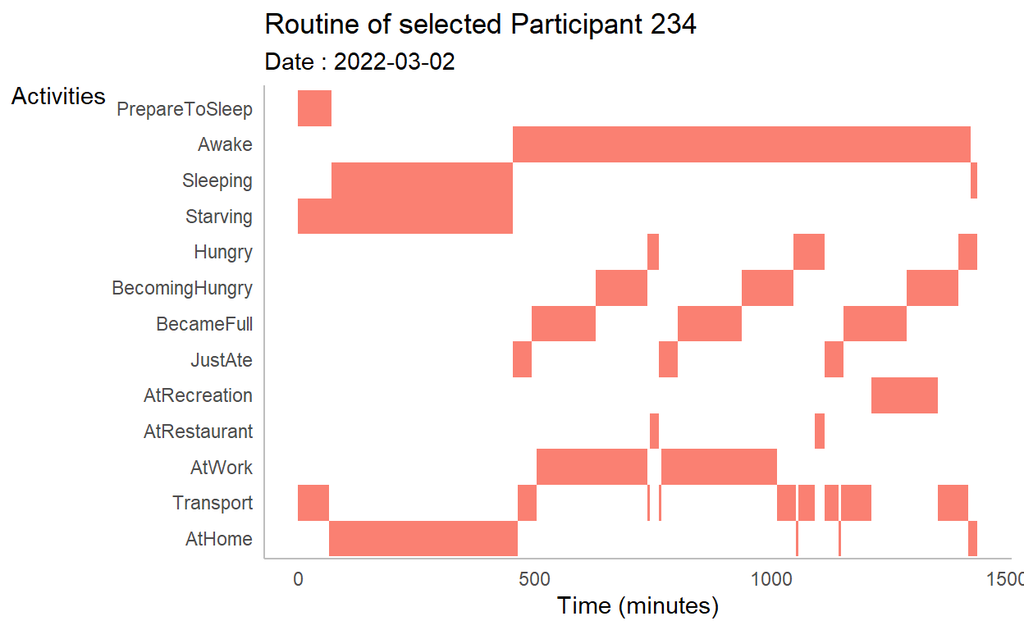

```r
pA1 <- pivot_tbl_A_1 %>%
        mutate(`Activities` = fct_relevel(Activities,
                                        "AtHome","Transport","AtWork","AtRestaurant","AtRecreation",
                                        "JustAte","BecameFull","BecomingHungry","Hungry","Starving",
                                        "Sleeping","Awake","PrepareToSleep")) %>%

        ggplot(aes(time, Activities, fill = as.factor(Statuses))) +
        geom_raster() +
        scale_fill_manual(values =  c("white","salmon")) +
        theme(legend.position = "none",
              axis.title.y = element_text(angle = 0),
              axis.text = element_text(),
              axis.ticks = element_blank(),
              panel.background = element_blank(),
              axis.line = element_line(color = 'grey'),
              panel.grid.minor.y = element_line(size = 0.2, colour = "grey70")) +
        labs(x = 'Time (minutes)',
             y = 'Activities',
             title = paste("Routine of selected Participant",participant_A),
             subtitle = paste('Date :', date_of_interest_1))

pA1
```

With that, the same code chunks (with the input dataframes varied) was applied for the other 3 charts that we are plotting. Scroll down to the bottom please.

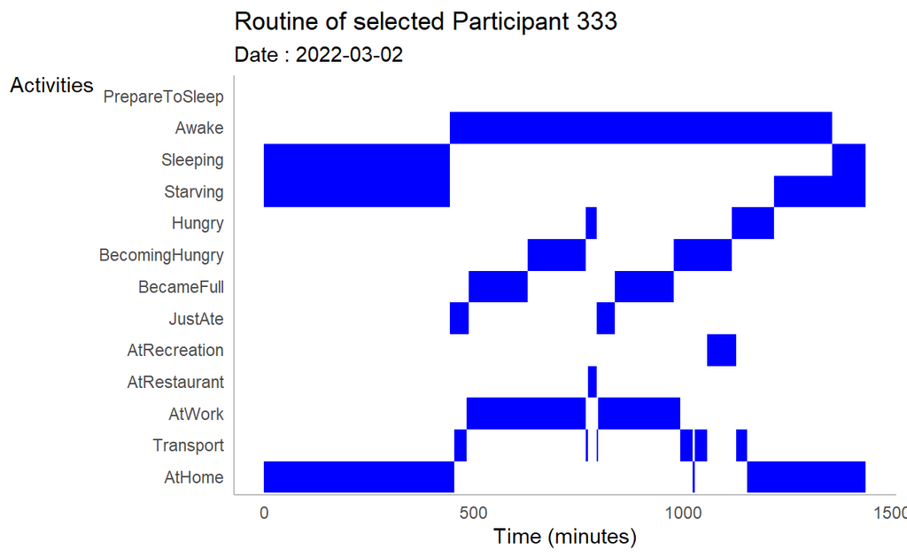

```r
pB1 <- pivot_tbl_B_1 %>%
        mutate(`Activities` = fct_relevel(Activities,
                                        "AtHome","Transport","AtWork","AtRestaurant","AtRecreation",
                                        "JustAte","BecameFull","BecomingHungry","Hungry","Starving",
                                        "Sleeping","Awake","PrepareToSleep")) %>%

        ggplot(aes(time, Activities, fill = as.factor(Statuses))) +
        geom_raster() +
        scale_fill_manual(values =  c("white","blue")) +
        theme(legend.position = "none",
              axis.title.y = element_text(angle = 0),
              axis.text = element_text(),
              axis.ticks = element_blank(),
              panel.background = element_blank(),
              axis.line = element_line(color = 'grey'),
              panel.grid.minor.y = element_line(size = 0.5, colour = "grey70")) +
        labs(x = 'Time (minutes)',
             y = 'Activities',
             title = paste("Routine of selected Participant",participant_B),
             subtitle = paste('Date :', date_of_interest_1))

pB1
```

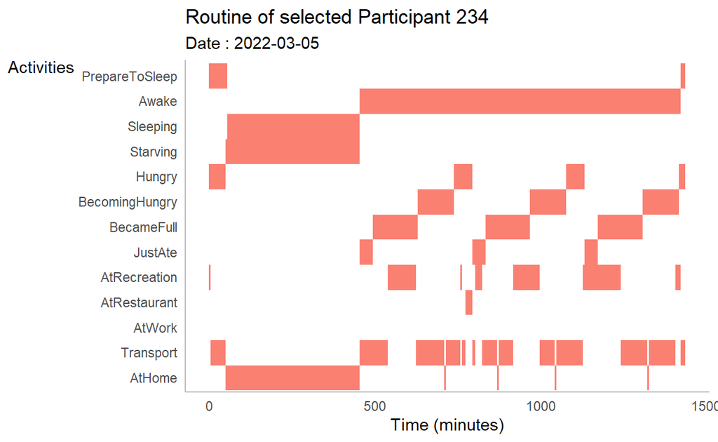

```r
pA2 <- pivot_tbl_A_2 %>%
        mutate(`Activities` = fct_relevel(Activities,
                                        "AtHome","Transport","AtWork","AtRestaurant","AtRecreation",
                                        "JustAte","BecameFull","BecomingHungry","Hungry","Starving",
                                        "Sleeping","Awake","PrepareToSleep")) %>%

        ggplot(aes(time, Activities, fill = as.factor(Statuses))) +
        geom_raster() +
        scale_fill_manual(values =  c("white","salmon")) +
        theme(legend.position = "none",
              axis.title.y = element_text(angle = 0),
              axis.text = element_text(),
              axis.ticks = element_blank(),
              panel.background = element_blank(),
              axis.line = element_line(color = 'grey'),
              panel.grid.minor.y = element_line(size = 0.5, colour = "grey70")) +
        labs(x = 'Time (minutes)',
             y = 'Activities',
             title = paste("Routine of selected Participant",participant_A),
             subtitle = paste('Date :', date_of_interest_2))

pA2
```

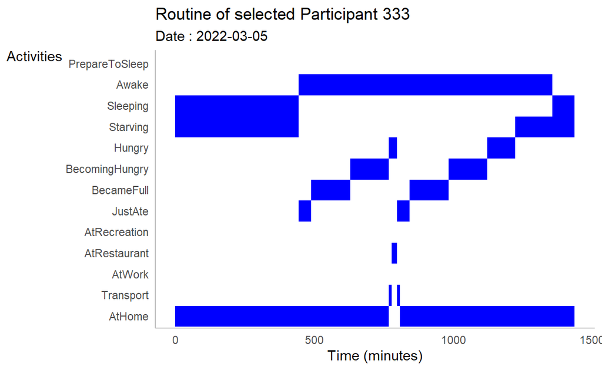

```r
pB2 <- pivot_tbl_B_2 %>%
        mutate(`Activities` = fct_relevel(Activities,
                                        "AtHome","Transport","AtWork","AtRestaurant","AtRecreation",
                                        "JustAte","BecameFull","BecomingHungry","Hungry","Starving",
                                        "Sleeping","Awake","PrepareToSleep")) %>%

        ggplot(aes(time, Activities, fill = as.factor(Statuses))) +
        geom_raster() +
        scale_fill_manual(values =  c("white","blue")) +
        theme(legend.position = "none",
              axis.title.y = element_text(angle = 0),
              axis.text = element_text(),
              axis.ticks = element_blank(),
              panel.background = element_blank(),
              axis.line = element_line(color = 'grey'),
              panel.grid.minor.y = element_line(size = 0.5, colour = "grey70")) +
        labs(x = 'Time (minutes)',
             y = 'Activities',
             title = paste("Routine of selected Participant",participant_B),
             subtitle = paste('Date :', date_of_interest_2))

pB2
```

## Presenting my patchwork…

Lastly, I am using the [patchwork](https://patchwork.data-imaginist.com/) package to stich all the 4 charts together for easier viewing and comparison.

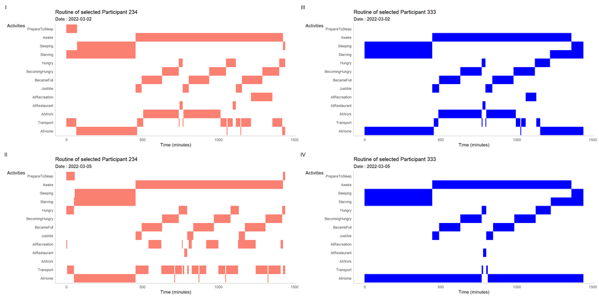

```r
((pA1 / pA2) | (pB1 / pB2)) +
plot_annotation(tag_levels = 'I')
```

### Observations:

It is quite clear that these 2 participants are having a largely different routine for their weekday and weekend.

Next would be to compare the participants’ routine on a weekend. Right off the bat, it is very obvious that weekend routine is much different from their weekdays’ counterpart.

Comparing Chart II (Participant 234; weekend) and Chart IV (Participant 333; weekend),

- Participant 333 spent his whole weekend at home, except for the period where he/she travelled out to a restaurant for mid-day meal
- Likewise, Participant 234 seems to spent bulk of his/her time outdoors instead of staying home like Participant 333
  - Multiple trips were also made during the weekend to travel to-and-fro his/her home to his/her recreational place
    - Also, it seems like there is some extensive travelling by foot (assumption) from the transport location to the recreational location as there was a block of varying size that was before and after the reacreational activity
- Similar to their weekdays’ pattern, Participant 234 is still having 1 more meal compared to Participant 333

In conclusion, it seems like Participant 234 is a much more active individual, especially for his/her recreational activity, compared to Participant 333 who typically do not eat dinner and spent practically whole weekend at home.